# Projeto Versão Final

```r
library(tidyverse)
library(here)
library(tidyr)
library(broom)
library(grid)

library(tidyverse)
theme_set(theme_bw())

library(ggbeeswarm)
library(gridExtra)
library(broom)


library(here)
library(tidyr)
library(broom)
library(boot)
```

```r
dados = read_csv(
  here("data/dados-extraidos.csv"),
  col_types =
    cols(
      Project = col_character(),
      Commits = col_double(),
      Developers = col_double(),
      Ocurr_nd = col_double(),
      Devs_nd = col_double(),
      Floss_nd = col_double(),
      Root_nd = col_double(),
      Ocurr_d = col_double(),
      Devs_d = col_double(),
      Floss_d = col_double(),
      Root_d = col_double(),
      Total_Ocorr = col_double()
    )
)

glimpse(dados)
```

```
## Rows: 37
## Columns: 12
## $ Project     <chr> "BfgMiner", "Busybox", "Cgminer", "Contiki", "CVS", "Dia",~
## $ Commits     <dbl> 12.651, 15.140, 7.911, 12.325, 8.405, 6.047, 2.389, 7.055,~
## $ Developers  <dbl> 93, 174, 76, 159, 10, 86, 11, 60, 239, 10, 99, 101, 4, 16,~
## $ Ocurr_nd    <dbl> 0, 1, 1, 1, 4, 1, 1, 2, 0, 4, 1, 2, 4, 5, 1, 2, 1, 1, 13, ~
## $ Devs_nd     <dbl> 0, 1, 1, 1, 3, 1, 1, 2, 0, 2, 1, 1, 1, 2, 1, 2, 1, 1, 2, 2~
## $ Floss_nd    <dbl> 0, 0, 0, 0, 4, 0, 0, 1, 0, 1, 0, 1, 1, 3, 0, 0, 1, 0, 11, ~
## $ Root_nd     <dbl> 0, 1, 1, 1, 0, 1, 1, 1, 0, 3, 1, 1, 3, 2, 1, 2, 0, 1, 2, 2~
## $ Ocurr_d     <dbl> 2, 13, 0, 0, 0, 0, 0, 0, 0, 0, 3, 0, 10, 2, 0, 0, 0, 0, 4,~
## $ Devs_d      <dbl> 2, 5, 0, 0, 0, 0, 0, 0, 0, 0, 1, 0, 2, 1, 0, 0, 0, 0, 2, 0~
## $ Floss_d     <dbl> 2, 8, 0, 0, 0, 0, 0, 0, 0, 0, 3, 0, 6, 2, 0, 0, 0, 0, 4, 0~
## $ Root_d      <dbl> 0, 5, 0, 0, 0, 0, 0, 0, 0, 0, 0, 0, 4, 0, 0, 0, 0, 0, 0, 0~
## $ Total_Ocorr <dbl> 2, 14, 1, 1, 4, 1, 1, 2, 0, 4, 4, 2, 14, 7, 1, 2, 1, 1, 17~
```

```r
dados_tabela2 = dados
```

```r
summary(dados_tabela2)
```

```
##    Project             Commits          Developers       Ocurr_nd
##  Length:37          Min.   :  1.091   Min.   :  1.0   Min.   : 0.000
##  Class :character   1st Qu.:  4.106   1st Qu.: 16.0   1st Qu.: 1.000
##  Mode  :character   Median :  8.405   Median : 76.0   Median : 1.000
##                     Mean   : 34.910   Mean   :115.9   Mean   : 3.297
##                     3rd Qu.: 15.304   3rd Qu.:129.0   3rd Qu.: 4.000
##                     Max.   :626.000   Max.   :875.0   Max.   :13.000
##     Devs_nd         Floss_nd         Root_nd         Ocurr_d
##  Min.   :0.000   Min.   : 0.000   Min.   :0.000   Min.   : 0.000
##  1st Qu.:1.000   1st Qu.: 0.000   1st Qu.:0.000   1st Qu.: 0.000
##  Median :1.000   Median : 1.000   Median :1.000   Median : 0.000
##  Mean   :1.622   Mean   : 1.757   Mean   :1.541   Mean   : 1.919
##  3rd Qu.:2.000   3rd Qu.: 2.000   3rd Qu.:2.000   3rd Qu.: 2.000
##  Max.   :7.000   Max.   :11.000   Max.   :8.000   Max.   :13.000
##      Devs_d         Floss_d           Root_d        Total_Ocorr
##  Min.   :0.000   Min.   : 0.000   Min.   :0.0000   Min.   : 0.000
##  1st Qu.:0.000   1st Qu.: 0.000   1st Qu.:0.0000   1st Qu.: 1.000
##  Median :0.000   Median : 0.000   Median :0.0000   Median : 2.000
##  Mean   :1.081   Mean   : 1.432   Mean   :0.4865   Mean   : 5.216
##  3rd Qu.:1.000   3rd Qu.: 2.000   3rd Qu.:0.0000   3rd Qu.: 7.000
##  Max.   :9.000   Max.   :10.000   Max.   :5.0000   Max.   :22.000
```

Correlação

```r
#A correlação entre a quantidade de commits e Disciplinado
#A correlação entre a quantidade de commits e Não Disciplinado

correlacao_Commits_AnotacaoNaoDiscipilinadas = dados_tabela2 %>%
      summarise(correlacao = cor(Commits, Ocurr_nd, method = "pearson"))%>%
    pull(correlacao)

correlacao_Commits_AnotacaoDiscipilinadas   = dados_tabela2 %>%
    summarise(correlacao = cor(Commits, Ocurr_d, method = "pearson"))%>%
    pull(correlacao)


pA1 = dados_tabela2 %>%
      ggplot(aes(x = Commits, y = Ocurr_nd)) +
      geom_point(alpha = .4, color = "green") +
      geom_vline (xintercept = mean (dados_tabela2$Commits), color = "red") +
      geom_hline (yintercept = mean (dados_tabela2$Ocurr_nd), color = "red") +
      geom_smooth(method=lm, se=FALSE) +
      annotate(geom = "text", x = 560, y = 4.9, label = paste("r = ", round(correlacao_Commits_AnotacaoNaoDiscipilinadas, 3)))


pA2 = dados_tabela2 %>%
      ggplot(aes(x = Commits, y = Ocurr_d)) +
      geom_point(alpha = .4, color = "green") +
      geom_vline (xintercept = mean (dados_tabela2$Commits), color = "red") +
      geom_hline (yintercept = mean (dados_tabela2$Ocurr_d), color = "red") +
      geom_smooth(method=lm, se=FALSE) +
      annotate(geom = "text", x = 530, y = 3.9, label = paste("r = ", round(correlacao_Commits_AnotacaoDiscipilinadas, 3)))


#grid.arrange(pA1, pA2, ncol = 2)
```

```r
#A correlação entre a quantidade de desenvolvedores e Disciplinado
#A correlação entre a quantidade de desenvolvedores e Não Disciplinado

correlacao_Developers_AnotacaoNaoDiscipilinadas = dados_tabela2 %>%
      summarise(correlacao = cor(Developers, Ocurr_nd, method = "pearson"))%>%
    pull(correlacao)

correlacao_Developers_AnotacaoDiscipilinadas   = dados_tabela2 %>%
    summarise(correlacao = cor(Developers, Ocurr_d, method = "pearson"))%>%
    pull(correlacao)


pB1 = dados_tabela2 %>%
      ggplot(aes(x = Developers, y = Ocurr_nd)) +
      geom_point(alpha = .4, color = "green") +
      geom_vline (xintercept = mean (dados_tabela2$Developers), color = "red") +
      geom_hline (yintercept = mean (dados_tabela2$Ocurr_nd), color = "red") +
      geom_smooth(method=lm, se=FALSE) +
      annotate(geom = "text", x = 560, y = 4.9, label = paste("r = ", round(correlacao_Developers_AnotacaoNaoDiscipilinadas, 3)))


pB2 = dados_tabela2 %>%
      ggplot(aes(x = Developers, y = Ocurr_d)) +
      geom_point(alpha = .4, color = "green") +
      geom_vline (xintercept = mean (dados_tabela2$Developers), color = "red") +
      geom_hline (yintercept = mean (dados_tabela2$Ocurr_d), color = "red") +
      geom_smooth(method=lm, se=FALSE) +
      annotate(geom = "text", x = 530, y = 3.9, label = paste("r = ", round(correlacao_Developers_AnotacaoDiscipilinadas, 3)))


#grid.arrange(pB1, pB2, ncol = 2)
```

```r
#A correlação entre a commits e macros

correlacao_Commits_Macros = dados_tabela2 %>%
      summarise(correlacao = cor(Commits, Total_Ocorr, method = "pearson"))%>%
    pull(correlacao)

correlacao_Developers_AnotacaoDiscipilinadas   = dados_tabela2 %>%
    summarise(correlacao = cor(Developers, Total_Ocorr, method = "pearson"))%>%
    pull(correlacao)


pC1 = dados_tabela2 %>%
      ggplot(aes(x = Commits, y = Total_Ocorr)) +
      geom_point(alpha = .4, color = "green") +
      geom_vline (xintercept = mean (dados_tabela2$Commits), color = "red") +
      geom_hline (yintercept = mean (dados_tabela2$Total_Ocorr), color = "red") +
      geom_smooth(method=lm, se=FALSE) +
      annotate(geom = "text", x = 560, y = 7.9, label = paste("r = ", round(correlacao_Commits_Macros, 3)))


pC2 = dados_tabela2 %>%
      ggplot(aes(x = Developers, y = Total_Ocorr)) +
      geom_point(alpha = .4, color = "green") +
      geom_vline (xintercept = mean (dados_tabela2$Developers), color = "red") +
      geom_hline (yintercept = mean (dados_tabela2$Total_Ocorr), color = "red") +
      geom_smooth(method=lm, se=FALSE) +
      annotate(geom = "text", x = 760, y = 7.9, label = paste("r = ", round(correlacao_Developers_AnotacaoDiscipilinadas, 3)))


#grid.arrange(pC1, pC2, ncol = 2)
```

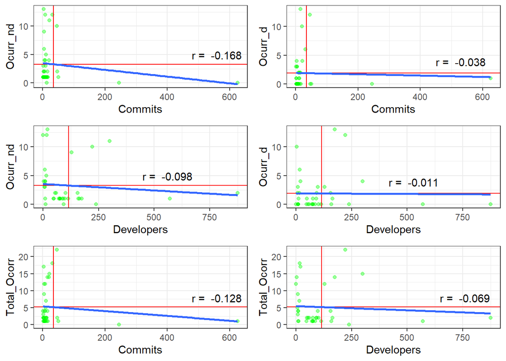

```r
grid.arrange(pA1, pA2, pB1, pB2, pC1, pC2, ncol = 2, nrow = 3)
```

Todas as correlações foram negativas, ou seja, as variáveis variam em sentido contrário. Se X aumenta, Y está diminuindo. E as correlações foram muito pequenas e próxima de zero. Ou seja, indicando uma associação linear fraca entres as várias.

```r
# Será unido os dados do tipo de anotacao e a quantidade de macros
# será criadno um campo com o nome da anotacao nd d e a quantidade de macros

dados_tabela2_NaoDisciplinado = dados_tabela2 %>%
  mutate(TipoAnotacao = "Não Disciplinada", Ocorr_nd_d = Ocurr_nd) %>%
  select(Project, TipoAnotacao, Ocorr_nd_d)

dados_tabela2_Disciplinado = dados_tabela2 %>%
  mutate(TipoAnotacao = 'Disciplinada', Ocorr_nd_d = Ocurr_d) %>%
  select(Project, TipoAnotacao, Ocorr_nd_d)

dados_tabela2_anotacoes = bind_rows(dados_tabela2_NaoDisciplinado, dados_tabela2_Disciplinado)
dados_tabela2_anotacoes
```

```
## # A tibble: 74 x 3
##    Project  TipoAnotacao     Ocorr_nd_d
##    <chr>    <chr>                 <dbl>
##  1 BfgMiner Não Disciplinada          0
##  2 Busybox  Não Disciplinada          1
##  3 Cgminer  Não Disciplinada          1
##  4 Contiki  Não Disciplinada          1
##  5 CVS      Não Disciplinada          4
##  6 Dia      Não Disciplinada          1
##  7 DynamRIO Não Disciplinada          1
##  8 Etlegacy Não Disciplinada          2
##  9 FreeBSD  Não Disciplinada          0
## 10 Fvwm     Não Disciplinada          4
## # ... with 64 more rows
```

A seguir são apresentados através do gráfico representado pelas frequências da Ocorr_nd_d para cada TipoAnotacao para melhor compreensão da distribuição das informações extraída.

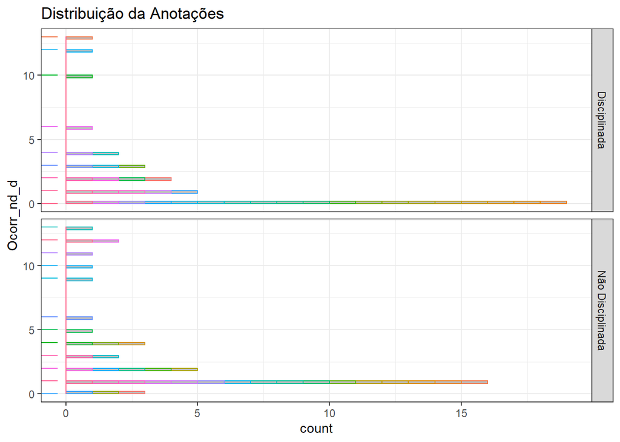

```r
dados_tabela2_anotacoes %>%
  ggplot(aes(y = Ocorr_nd_d, color = Project)) +
  geom_histogram(binwidth = .2, alpha = .4, boundary = 0) +
  geom_rug() +
  facet_grid(TipoAnotacao ~., scales = "free_y") +
  labs(title = "Distribuição da Anotações") +
  theme(legend.position = "None")
```

Desvio padrão para Anotações:

```r
Desvio_Padrao_D = dados_tabela2_anotacoes %>%
  filter (TipoAnotacao == "Disciplinada") %>%
  select (Ocorr_nd_d)

# Desvio padrão
sd(Desvio_Padrao_D$Ocorr_nd_d)
```

```
## [1] 3.303015
```

```r
Desvio_Padrao_ND = dados_tabela2_anotacoes %>%
  filter (TipoAnotacao == "Não Disciplinada") %>%
  select (Ocorr_nd_d)

# Desvio padrão
sd(Desvio_Padrao_ND$Ocorr_nd_d)
```

```
## [1] 3.799597
```

Total de registros:

```r
Total =  length(dados_tabela2_anotacoes$Ocorr_nd_d)
Total
```

```
## [1] 74
```

Para realização da estimará ICs usando bootstrap são coletadas as informações apresentadas nesta seção, no qual são realizadas as organizações em tabelas dos tipos de anotações, quantidade e percentual, além que são realizados os cálculos necessários.

```r
dados_tabela2_anotacoes %>%
     count(TipoAnotacao) %>% mutate (Percentual = round ((n / Total) * 100))
```

```
## # A tibble: 2 x 3
##   TipoAnotacao         n Percentual
##   <chr>            <int>      <dbl>
## 1 Disciplinada        37         50
## 2 Não Disciplinada    37         50
```

```r
agrupado = dados_tabela2_anotacoes %>%
    group_by(TipoAnotacao) %>%
    summarise(media = mean(Ocorr_nd_d),  .groups = "drop")
agrupado
```

```
## # A tibble: 2 x 2
##   TipoAnotacao     media
##   <chr>            <dbl>
## 1 Disciplinada      1.92
## 2 Não Disciplinada  3.30
```

```r
a = agrupado %>% filter(TipoAnotacao == "Disciplinada")         %>% pull(media)
b = agrupado %>% filter(TipoAnotacao == "Não Disciplinada")     %>% pull(media)
b - a
```

```
## [1] 1.378378
```

```r
comparacao1 = dados_tabela2_anotacoes %>%
    filter(TipoAnotacao %in% c("Disciplinada", "Não Disciplinada"))


theta1 <- function(d, i) {
    agrupado = d %>%
        slice(i) %>%
        group_by(TipoAnotacao) %>%
        summarise(media = mean(Ocorr_nd_d))
        a = agrupado %>% filter(TipoAnotacao == "Disciplinada")         %>% pull(media)
        b = agrupado %>% filter(TipoAnotacao == "Não Disciplinada")     %>% pull(media)
        b - a
}

theta1(comparacao1, i = 1:NROW(comparacao1))
```

```
## [1] 1.378378
```

```r
ci1 = boot(data = comparacao1,
           statistic = theta1,
           R = 2000) %>%
    tidy(conf.level = .95,
         conf.method = "bca",
         conf.int = TRUE) %>%

    mutate (tamanho_conf.high_conf.low = conf.high - conf.low)

ci1
```

```
## # A tibble: 1 x 6
##   statistic   bias std.error conf.low conf.high tamanho_conf.high_conf.low
##       <dbl>  <dbl>     <dbl>    <dbl>     <dbl>                      <dbl>
## 1      1.38 0.0296     0.836   -0.229      3.09                       3.32
```

Para a visualização dos efeitos de interesse para a comparação entre as duas anotações é realizado a diferença entre a média do TipoAnotacao de Ocorr_nd_n. Os gráficos contém a “Ocorr a cada TipoAnotacao”, " com médias e medianas a cada TipoAnotacao" e “Diferença das médias” em que são apresentados contendo as informações já calculadas do campo Ocorr, suas médias (em vermelho) e medianas (em azul). Também contém a diferença para os TipoAnotacao “Não Disciplinada - Disciplinada”

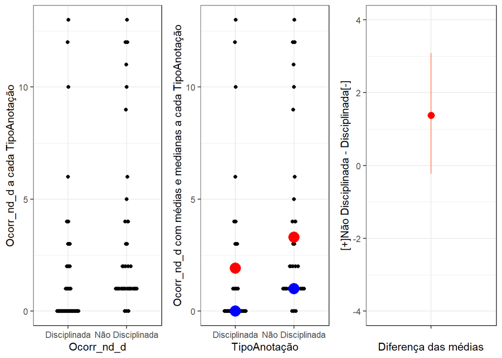

```r
p1 = comparacao1 %>%
    ggplot(aes(x = TipoAnotacao, y = Ocorr_nd_d)) +
    geom_quasirandom(width = .2, position = "quasirandom") +
    labs(x = "Ocorr_nd_d",
         y = "Ocorr_nd_d a cada TipoAnotação")

p2 = comparacao1 %>%
    ggplot(aes(x = TipoAnotacao, y = Ocorr_nd_d)) +
    geom_quasirandom(width = .2, position = "quasirandom") +
    stat_summary(geom = "point", fun = "mean", color = "red", size = 5) +
    stat_summary(geom = "point", fun = "median", color = "blue", size = 5) +
    labs(x = "TipoAnotação",
         y = "Ocorr_nd_d com médias e medianas a cada TipoAnotação")


p3 = ci1 %>%
    ggplot(aes(
        x = "",
        y = statistic,
        ymin = conf.low,
        ymax = conf.high
    )) +
    geom_pointrange(color = "coral") +
    geom_point(size = 3, color = "red") +
    scale_y_continuous(limits = c(-4, 4)) +
    labs(x = "Diferença das médias",
         y = "[+]Não Disciplinada - Disciplinada[-]")

grid.arrange(p1, p2, p3, ncol = 3)
```

**Conclusão sobre a interpretação das informações apresentadas nesta seção TipoAnotacao “Não Disciplinada - Disciplinada”**

Tomando como base o estudo original aplicada para determinada finalidade acadêmica, , analisou-se as informações sobre o tamanho do efeito dos tipos de anotações comparada com a Disciplinada e Não Disciplinada.

Para isto, foram observados a população N = 37, obtido a amostras n = 74, que foram dividas em dois grupos através dos seus respectivo campo de anotações “Não Disciplinado” = 37 (50%) e “Disciplinado” = 37 (50%), a representatividade a ser comparada que determinada a relação dos dados são apresentadas pelo campo TipoAnotacao no qual todas estas informações são fornecidas através do histórico de commits dos códigos-fontes dos sistemas configuráveis através do GitHub que foram disponbilizadas estas informações em formato de tabela.

Inicialmente, através do campo Ocorr_nd_n, os dois gráficos da Distribuição da Anotações está entre os valores entre 0 e 13.

No gráfico Distribuição da Anotações pode ser melhor observado maior concentração da satisfaction nos valores na ordem para o grupo Não Disciplinado. Em ambos gupos há maior concentração de valores entre 0 e 2 para muito projetos. As informações também pode ser observado através das médias Não Disciplinada=3.30 e Disciplinada=1.92 de maneira comparativa ambas as distribuições.

Após a realização dos procedimentos necessários foram obtidos para TipoAnotacaoos valores do Desvio Padrão para o grupos “Não Disciplinada” = 3.799597 e Desvio Padrão para o “Disciplinada” = 3.303015. A média para os grupos Não Disciplinada=3.30 e Disciplinada=1.92, neste contexto o “Não Disciplinada” foi o possui maior média. E a diferença média (“Não Disciplinada” - “Disciplinada”) resultou em 1.38. No gráfico “Ocorr_nd_d com médias e medianas a cada TipoAnotação” com médias e medianas a cada TipoAnotacao foi realizado a média e a mediana no qual os seus valores teve considerável variações, principalmente para o grupo “Não Disciplinada”, sendo que no geral a média e a mediana contém valores distantes, por isso, foi realizado o uso da média. No caso da diferença entre as médias e mediana pelo que foi observado ocorreu por causa, valores da Ocorr_nd_d são altos comparados aos demais o que pode ter influenciado para a diferença.

```r
#dados_tabela2_melhor = dados_tabela2 %>%
#  mutate(TipoAnotacao = 'Não Disciplinada', Ocorr_nd_d = Ocurr_nd) %>%
#  select(Project, TipoAnotacao, Ocorr_nd_d)
```

Para realização da estimava ICs usando bootstrap foram realizadas diversas tentativas com os dados disponíveis e não foi possível ser relizado de maneira indêncio ao estudo Original, Entre o Macro(Total_Ocorr) dos Commits para cada projeto. Neste sentido, foi então realizado um tentativa no eixo x = Total_Ocorr / Commits, ou seja, seria a média, o no eixo y = Project. Sendo assim, são apresentado os respectivos resultados a seguir:

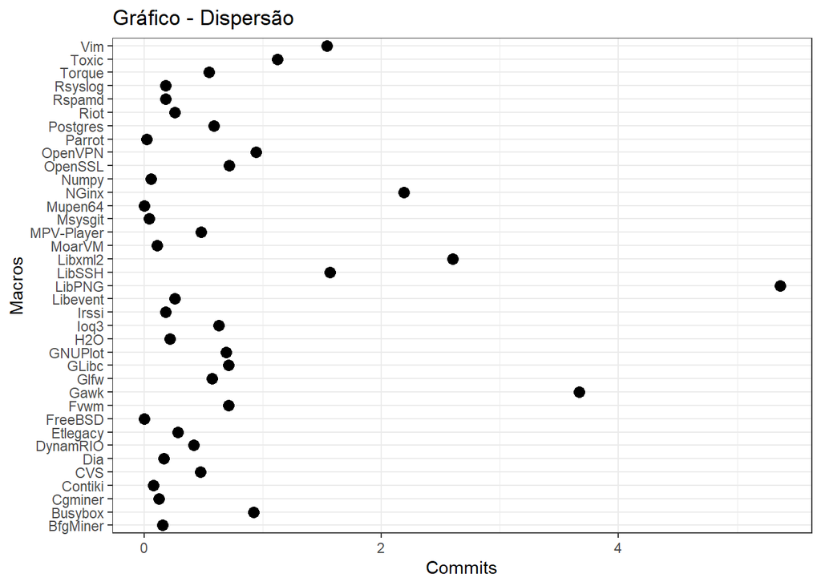

```r
dados_tabela2 %>% ggplot(aes(x = Total_Ocorr / Commits, y = Project)) +
#         geom_linerange(color = "green") +
#        geom_point(color = "coral", size = 2) +
        geom_point(size = 3) +
##        geom_point(aes(color=Project))+
        #geom_point(aes(Project = 'Dia'), size = 5) +
        #facet_grid(scenario ~., scales = "free_y") +
        labs(x = "Commits", y = "Macros", title = "Gráfico - Dispersão")
```

```r
#        coord_flip()
```

```r
dados %>%
  count(Project)
```

```
## # A tibble: 37 x 2
##    Project      n
##    <chr>    <int>
##  1 BfgMiner     1
##  2 Busybox      1
##  3 Cgminer      1
##  4 Contiki      1
##  5 CVS          1
##  6 Dia          1
##  7 DynamRIO     1
##  8 Etlegacy     1
##  9 FreeBSD      1
## 10 Fvwm         1
## # ... with 27 more rows
```

```r
dados_mineracao = dados %>%
  select (Total_Ocorr, Commits, Project)

glimpse(dados_mineracao)
```

```
## Rows: 37
## Columns: 3
## $ Total_Ocorr <dbl> 2, 14, 1, 1, 4, 1, 1, 2, 0, 4, 4, 2, 14, 7, 1, 2, 1, 1, 17~
## $ Commits     <dbl> 12.651, 15.140, 7.911, 12.325, 8.405, 6.047, 2.389, 7.055,~
## $ Project     <chr> "BfgMiner", "Busybox", "Cgminer", "Contiki", "CVS", "Dia",~
```

```r
theta <- function(d, i) {
    agrupado = d %>%
        slice(i) %>%
        group_by(Project) %>%
        summarise(media = Total_Ocorr/Commits, .groups = "drop")
        a = agrupado %>% pull(media)
        a
}

booted <- boot(data = dados,
               statistic = theta,
               R = 2000)

ci = tidy(booted,
          conf.level = .95,
          conf.int = TRUE)

glimpse(ci)
```

```
## Rows: 37
## Columns: 5
## $ statistic <dbl> 0.158090270, 0.924702774, 0.126406270, 0.081135903, 0.475907~
## $ bias      <dbl> 0.1827902, -0.5035123, 0.2344674, 0.2370097, -0.1544099, 0.2~
## $ std.error <dbl> 0.3307062, 0.3690157, 0.3584425, 0.3276319, 0.3850814, 0.571~
## $ conf.low  <dbl> 0.081135903, 0.081135903, 0.081135903, 0.081135903, 0.000000~
## $ conf.high <dbl> 0.9247028, 0.9247028, 0.9247028, 0.9247028, 0.9247028, 3.666~
```

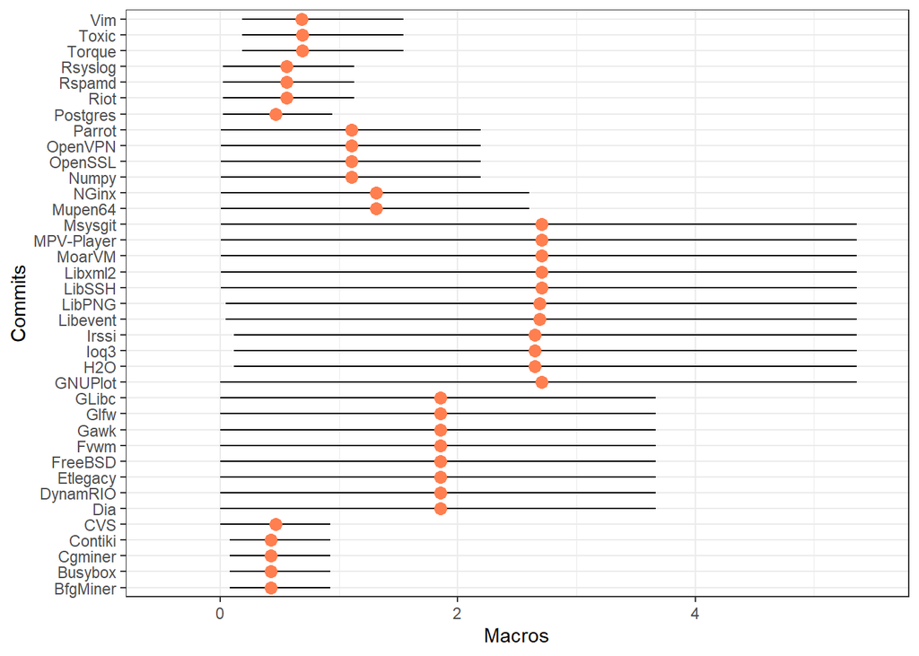

```r
plot_ics = function(d) {
    d %>%
        ggplot(aes(
            xmin = low,
            x = mid,
            xmax = high,
            y = metodo
        )) +

        geom_linerange() +
        geom_point(color = "coral", size = 3) +
        scale_x_continuous(limits = c(-0.5, 5.5)) +
        labs(y = "Commits", x = "Macros")

}

MetadeFator = 1.98
tribble(
    ~metodo, ~low, ~mid, ~high,
    dados_mineracao$Project[01], ci$conf.low [01], (ci$conf.high[01] - ci$conf.low [01]) / MetadeFator, ci$conf.high[01],
    dados_mineracao$Project[02], ci$conf.low [02], (ci$conf.high[02] - ci$conf.low [02]) / MetadeFator, ci$conf.high[02],
    dados_mineracao$Project[03], ci$conf.low [03], (ci$conf.high[03] - ci$conf.low [03]) / MetadeFator, ci$conf.high[03],
    dados_mineracao$Project[04], ci$conf.low [04], (ci$conf.high[04] - ci$conf.low [04]) / MetadeFator, ci$conf.high[04],
    dados_mineracao$Project[05], ci$conf.low [05], (ci$conf.high[05] - ci$conf.low [05]) / MetadeFator, ci$conf.high[05],
    dados_mineracao$Project[06], ci$conf.low [06], (ci$conf.high[06] - ci$conf.low [06]) / MetadeFator, ci$conf.high[06],
    dados_mineracao$Project[07], ci$conf.low [07], (ci$conf.high[07] - ci$conf.low [07]) / MetadeFator, ci$conf.high[07],
    dados_mineracao$Project[08], ci$conf.low [08], (ci$conf.high[08] - ci$conf.low [08]) / MetadeFator, ci$conf.high[08],
    dados_mineracao$Project[09], ci$conf.low [09], (ci$conf.high[09] - ci$conf.low [09]) / MetadeFator, ci$conf.high[09],
    dados_mineracao$Project[10], ci$conf.low [10], (ci$conf.high[10] - ci$conf.low [10]) / MetadeFator, ci$conf.high[10],
    dados_mineracao$Project[11], ci$conf.low [11], (ci$conf.high[11] - ci$conf.low [11]) / MetadeFator, ci$conf.high[11],
    dados_mineracao$Project[12], ci$conf.low [12], (ci$conf.high[12] - ci$conf.low [12]) / MetadeFator, ci$conf.high[12],
    dados_mineracao$Project[13], ci$conf.low [13], (ci$conf.high[13] - ci$conf.low [13]) / MetadeFator, ci$conf.high[13],
    dados_mineracao$Project[14], ci$conf.low [14], (ci$conf.high[14] - ci$conf.low [14]) / MetadeFator, ci$conf.high[14],
    dados_mineracao$Project[15], ci$conf.low [15], (ci$conf.high[15] - ci$conf.low [15]) / MetadeFator, ci$conf.high[15],
    dados_mineracao$Project[16], ci$conf.low [16], (ci$conf.high[16] - ci$conf.low [16]) / MetadeFator, ci$conf.high[16],
    dados_mineracao$Project[17], ci$conf.low [17], (ci$conf.high[17] - ci$conf.low [17]) / MetadeFator, ci$conf.high[17],
    dados_mineracao$Project[18], ci$conf.low [18], (ci$conf.high[18] - ci$conf.low [18]) / MetadeFator, ci$conf.high[18],
    dados_mineracao$Project[19], ci$conf.low [19], (ci$conf.high[19] - ci$conf.low [19]) / MetadeFator, ci$conf.high[19],
    dados_mineracao$Project[20], ci$conf.low [20], (ci$conf.high[20] - ci$conf.low [20]) / MetadeFator, ci$conf.high[20],
    dados_mineracao$Project[21], ci$conf.low [21], (ci$conf.high[21] - ci$conf.low [21]) / MetadeFator, ci$conf.high[21],
    dados_mineracao$Project[22], ci$conf.low [22], (ci$conf.high[22] - ci$conf.low [22]) / MetadeFator, ci$conf.high[22],
    dados_mineracao$Project[23], ci$conf.low [23], (ci$conf.high[23] - ci$conf.low [23]) / MetadeFator, ci$conf.high[23],
    dados_mineracao$Project[24], ci$conf.low [24], (ci$conf.high[24] - ci$conf.low [24]) / MetadeFator, ci$conf.high[24],
    dados_mineracao$Project[25], ci$conf.low [25], (ci$conf.high[25] - ci$conf.low [25]) / MetadeFator, ci$conf.high[25],
    dados_mineracao$Project[26], ci$conf.low [26], (ci$conf.high[26] - ci$conf.low [26]) / MetadeFator, ci$conf.high[26],
    dados_mineracao$Project[27], ci$conf.low [27], (ci$conf.high[27] - ci$conf.low [27]) / MetadeFator, ci$conf.high[27],
    dados_mineracao$Project[28], ci$conf.low [28], (ci$conf.high[28] - ci$conf.low [28]) / MetadeFator, ci$conf.high[28],
    dados_mineracao$Project[29], ci$conf.low [29], (ci$conf.high[29] - ci$conf.low [29]) / MetadeFator, ci$conf.high[29],
    dados_mineracao$Project[30], ci$conf.low [30], (ci$conf.high[30] - ci$conf.low [30]) / MetadeFator, ci$conf.high[30],
    dados_mineracao$Project[31], ci$conf.low [31], (ci$conf.high[31] - ci$conf.low [31]) / MetadeFator, ci$conf.high[31],
    dados_mineracao$Project[32], ci$conf.low [32], (ci$conf.high[32] - ci$conf.low [32]) / MetadeFator, ci$conf.high[32],
    dados_mineracao$Project[33], ci$conf.low [33], (ci$conf.high[33] - ci$conf.low [33]) / MetadeFator, ci$conf.high[33],
    dados_mineracao$Project[34], ci$conf.low [34], (ci$conf.high[34] - ci$conf.low [34]) / MetadeFator, ci$conf.high[34],
    dados_mineracao$Project[35], ci$conf.low [35], (ci$conf.high[35] - ci$conf.low [35]) / MetadeFator, ci$conf.high[35],
    dados_mineracao$Project[36], ci$conf.low [36], (ci$conf.high[36] - ci$conf.low [36]) / MetadeFator, ci$conf.high[36],
    dados_mineracao$Project[37], ci$conf.low [37], (ci$conf.high[37] - ci$conf.low [37]) / MetadeFator, ci$conf.high[37]) %>%
    plot_ics()
```

Observando o Gráfico indica que os efeitos foram divididos em poucos grupos contém uma diferença grande entre o limite inferior e superior e mostra poucas informações que podem ser afirmadas para a maioria dos projetos.